# Combining R & Python in RStudio - a problem-based tutorial with solutions

Michael Stadler

April 27, 2022

# 1 Preparing the working environment

If you have not already done that, you may use the `Terminal` panel of RStudio to access bash and use `git` to checkout the course repository into your working directory:

```bash
cd ~/workdir
git clone https://github.com/fmicompbio/adv_singlecell_2022.git
```

# 2 Introduction

In this problem-based tutorial, we will work with RStudio as an editor and use its support for code from different languages, in particular R and Python.

## 2.1 Useful links

These might help you if you get stuck in solving the problems below, or for future reference:

- “R Markdown: The Definitive Guide” (free online book): https://bookdown.org/yihui/rmarkdown/
- `knitr` chunk options: https://yihui.org/knitr/options/
- `reticulate` documenation (R interface to Python): https://rstudio.github.io/reticulate/
- `reticulate` and sparse matrices: https://rstudio.github.io/reticulate/articles/calling_python.html#sparse-matrices
- `reticulate` webinar: https://resources.rstudio.com/webinars/r-python-in-rstudio-1-2-with-reticulate
- “Debunking the R vs. Python Myth” webinar: https://www.rstudio.com/resources/webinars/debunking-the-r-vs-python-myth/
- PyCon.DE 2018: “Reticulate: R Interface To Python” (presentation by Jens Bruno Wittek): https://www.youtube.com/watch?v=EJxQSa9lwfM
- Tutorial for using Python in RStudio: https://docs.rstudio.com/tutorials/user/using-python-with-rstudio-and-reticulate/
- `SciPy` documenation: https://docs.scipy.org/doc/scipy/reference/
- `pandas.DataFrame` documentation: https://pandas.pydata.org/pandas-docs/stable/reference/api/pandas.DataFrame.html
- `matplotlib` documentation: https://matplotlib.org/
- `ggplot2` documentation: https://ggplot2.tidyverse.org/

## 2.2 Using `Rmarkdown` in RStudio

### 2.2.1 `Rmarkdown` documents

In this tutorial you should create an `Rmarkdown` document (`.Rmd` file extension), which is a `markdown` document (plain text with human-friendly formatting cues, see this [article](https://en.wikipedia.org/wiki/Markdown) on Wikipedia) that can include chunks of code.

When the document is rendered into a pretty output format (for example HTML, PDF or Word), the code is run and its output (text or figures) is captured and included in the output file. This makes it a great tool to document and share reproducible analyses.

### 2.2.2 Defining code chunks

For code chunks, multiple languages are supported by RStudio (see [link](https://bookdown.org/yihui/rmarkdown/language-engines.html) for a list). Code chunks are delineated by three backticks (```), and the language is defined in the header:

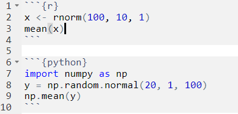

In addition to the language, additional options that apply to that chunk can be defined in the header, such as:

- `fig.width` and `fig.height` control the dimensions of generated figures
- `warnings=FALSE` suppresses warnings
- `echo=FALSE` hides the code in the output
- `eval=FALSE` does not run a code chunk

You can find more details on chunk options supported by `knitr`, RStudio’s default engine, [here](https://yihui.org/knitr/options/).

I use different background colors to indicate code chunks for different languages. These will only become visible in the rendered output document and are defined in a CSS file (selected by `class.source`).

```r
# R code
R.version.string
```

```python
# python code
import sys
sys.version
```

```bash
# shell script (bash)
echo ${BASH_VERSION}
```

## 2.3 Connecting RStudio to Python with `reticulate`

Combining R and Python is made possible using the [reticulate](https://rstudio.github.io/reticulate/) package. It has been created by developers at RStudio (JJ Allaire and Kevin Ushey) and is compatible with Python >= 2.7 and numpy >= 1.6.

It can be installed from [CRAN](https://cran.r-project.org/) using the code below (this is not needed on your virtual machine - it is already installed):

```r
install.packages("reticulate")
```

### 2.3.1 Selecting which Python to use

The Python instance to be used by [reticulate](https://rstudio.github.io/reticulate/) should be selected at the beginning of an analysis, before the Python process is started.

You can use `py_available()` to check if Python is available on the system and has already been initialized, and `py_discover_config()` if you want to select one from several potential Python instances that provides specific required modules:

```r
# load reticulate package
library(reticulate)

# check if Python is available and has already been initialized
py_available()
```

```
## [1] FALSE
```

```r
# discover Python that provides "numpy"
py_discover_config(required_module = "numpy")
```

```
## python:         /Users/stadler/miniforge3/bin/python3
## libpython:      /Users/stadler/miniforge3/lib/libpython3.9.dylib
## pythonhome:     /Users/stadler/miniforge3:/Users/stadler/miniforge3
## version:        3.9.12 | packaged by conda-forge | (main, Mar 24 2022, 23:24:38)  [Clang 12.0.1 ]
## numpy:          /Users/stadler/miniforge3/lib/python3.9/site-packages/numpy
## numpy_version:  1.21.5
## numpy:          /Users/stadler/miniforge3/lib/python3.9/site-packages/numpy
##
## python versions found:
##  /Users/stadler/miniforge3/bin/python3
##  /Users/stadler/miniforge3/bin/python
```

By default, [reticulate](https://rstudio.github.io/reticulate/) uses the version of Python found on your PATH (i.e. `Sys.which("python")`). The `use_python()` function, or the `RETICULATE_PYTHON` environment variable enable you to specify an alternate version.

You can also use Python from a virtual or `Conda` environment using the `use_virtualenv()` and `use_condaenv()` functions. See this [link](https://rstudio.github.io/reticulate/articles/versions.html) for more details.

Finally, environments can also be created, and Python packages can be installed or removed, from within R using the following functions:

- *Conda environments*: `conda_create()`, `conda_install()`, `conda_remove()`
- *Virtual environments*: `virtualenv_create()`, `virtualenv_install()`, `virtualenv_remove()`
- *active environment* (or if unset, the `r-reticulate` environment): `py_install()`

For this course, the virtual machine has all required Python packages already installed into the `conda` environment `"day1_RNA_velocity"`. We will select this using `use_condaenv()` below.

On my local server, which I use to write this documentation, I am using a different environment that is configured in a local file (`FMI_python_config.R`).

Finally, after we have selected a Python environment or path using one of the above mechanisms, we can use `py_config()` to connect to it. If you run `py_config()` and Python bindings have not been initialized yet, they will be initialized by that function:

```r
# set Python env (only needed on server xenon6)
if (file.exists("FMI_python_config.R")) {
    # setup for FMI server
    source("FMI_python_config.R")
} else {
    # setup for cloud VM
    Sys.setenv(PYTHONPATH = "/home/rstudio/.local/share/r-miniconda/envs/day1_python_and_R/lib/python3.8/site-packages/")
    reticulate::use_condaenv("day1_RNA_velocity", required = TRUE)
}

# print config (will initialize Python bindings)
py_config()
```

```
## python:         /Users/stadler/Documents/FMI/teaching/adv_singlecell_2022/day1_python_and_R/pythonenv/bin/python
## libpython:      /Users/stadler/Documents/FMI/teaching/adv_singlecell_2022/day1_python_and_R/pythonenv/lib/libpython3.9.dylib
## pythonhome:     /Users/stadler/Documents/FMI/teaching/adv_singlecell_2022/day1_python_and_R/pythonenv:/Users/stadler/Documents/FMI/teaching/adv_singlecell_2022/day1_python_and_R/pythonenv
## version:        3.9.12 | packaged by conda-forge | (main, Mar 24 2022, 23:24:38)  [Clang 12.0.1 ]
## numpy:          /Users/stadler/Documents/FMI/teaching/adv_singlecell_2022/day1_python_and_R/pythonenv/lib/python3.9/site-packages/numpy
## numpy_version:  1.22.3
##
## NOTE: Python version was forced by use_python function
```

```r
# check if Python is available now
py_available()
```

```
## [1] TRUE
```

### 2.3.2 The `reticulate` Python engine

The integration of R and Python in RStudio is more sophisticated than that of other languages that can be run in code chunks. The Python engine from [reticulate](https://rstudio.github.io/reticulate/) allows you to:

1. run Python chunks (single Python session connected to your R session, shared variables/state between Python chunks)
2. print Python output (including graphical output from [matplotlib](https://matplotlib.org/)
3. access Python objects from R (using the `py` object)
4. access R objects from Python (using the `r` object)

# 3 Exercises

## 3.1 Create a new `Rmarkdown` file

You can either write one from scratch or using RStudio’s `File` –> `New File`. The latter will pre-fill the document with sample content and is also helpful to get you started with the `yaml` header (configure block at the top, separated by the `---` marks).

All exercises can be written into this document.

## 3.2 Add an R code chunk to the document that generates text and/or figure outputs

You can execute code interactively (line-by-line or the whole chunk), and you can also compile the whole document (`Knit` button on top). It is good practise to compile the whole document from time to time, and most importantly at the end.

## 3.3 Add an R code chunk that select and initializes Python

This code chunk should be one of the first in your document, and it should contain this:

```python
# set Python module path and select Python from conda environment
Sys.setenv(PYTHONPATH = "/home/rstudio/.local/share/r-miniconda/envs/day1_python_and_R/lib/python3.8/site-packages/")
reticulate::use_condaenv("day1_RNA_velocity", required = TRUE)

# print config (will initialize Python bindings)
py_config()

# check if Python is available now
py_available()
```

You know that this was successful if `py_available()` returns `TRUE`.

## 3.4 Start an interactive Python prompt in your R console

- You can use `repl_python()` in your console to start a **R**read-**E**valuate-**P**rint **L**oop to interact with Python.
- Try to create some objects (e.g. `x = 1` or `a = [1, 2, 3]`).
- You can leave the loop by typing `exit`, which brings you back to the R console.

```python
x = 1
a = [1, 2, 3]
```

## 3.5 Add a Python code chunk to your document

- This should be below the Python init block.
- Is it using the same Python process as the REPL above, or in other words, do the objects created in the REPL persist and are they available in a subsequent code chunk? Try to check this.

```python
x
```

```
## 1
```

```python
a
```

```
## [1, 2, 3]
```

You may have noticed that when you run a code chunk interactively in RStudio (e.g. by pressing Ctrl-Enter, or clicking on the ‘play’ button), RStudio will automatically enter the REPL and also leave it automatically again when you run R code interactively.

## 3.6 Do separate Python code chunks use the same Python process?

- Do objects created in one Python chunk persist and can they be accessed in a subsequent Python chunk? You can test this by adding two more Python chunks to your document and try it out.

```python
x = 1
a = [1, 2, 3]
```

```python
x
```

```
## 1
```

```python
a[1]
```

```
## 2
```

## 3.7 Access Python objects from an R code chunk

- In your R chunk, use the special `py` object to access objects that live in the Python process, for example `py$x`
- What is the R object type for different types of Python objects (e.g. `scalar`, `list`, `dict`, etc.)?

```python
x = 1
a = [1, 2, 3]
d = {'a': 1, 'b': 'B'}

type(x)
```

```
## <class 'int'>
```

```python
type(a)
```

```
## <class 'list'>
```

```python
type(d)
```

```
## <class 'dict'>
```

```r
py$x
```

```
## [1] 1
```

```r
py$a
```

```
## [1] 1 2 3
```

```r
py$d
```

```
## $a
## [1] 1
##
## $b
## [1] "B"
```

```r
str(py$x)
```

```
##  int 1
```

```r
str(py$a)
```

```
##  int [1:3] 1 2 3
```

```r
str(py$d)
```

```
## List of 2
##  $ a: int 1
##  $ b: chr "B"
```

You may have observed that automated type conversions happen when you access Python objects from R or vice versa. The following table summarizes the currently supported conversions:

### 3.7.1 Type conversions between R and Python

See also https://rstudio.github.io/reticulate/articles/calling_python.html#type-conversions

| R | Python | Examples |
| --- | --- | --- |
| Single-element vector | Scalar | 1, 1L, TRUE, “foo” |
| Multi-element vector | List | c(1.0, 2.0, 3.0), c(1L, 2L, 3L) |
| List of multiple types | Tuple | list(1L, TRUE, “foo”) |
| Named list | Dict | list(a = 1L, b = 2.0), dict(x = x_data) |
| Matrix/Array | NumPy ndarray | matrix(c(1,2,3,4), nrow = 2, ncol = 2) |
| Data Frame | Pandas DataFrame | data.frame(x = c(1,2,3), y = c(“a”, “b”, “c”)) |
| Function | Python function | function(x) x + 1 |
| Raw | Python bytearray | as.raw(c(1:10)) |
| NULL, TRUE, FALSE | None, True, False | NULL, TRUE, FALSE |

## 3.8 Access R objects from an Python code chunk

Let’s do some more exercises to illustrate object access:

- Create numerical vectors with 100 values drawn from normal distributions (choosing your own mean and standard deviation), one in R called `n1` and one in Python called `n2`. Hint: You can use the `rnorm()` function in R and the `numpy.random.normal()` function in Python to sample from a normal distribution.

```r
n1 <- rnorm(100, 10, 1)
```

```python
import numpy as np
n2 = np.random.normal(20, 1, 100)
```

- Calculate the mean of `n1` and `n2`, both in R and in Python. Hint: You can use the `mean()` and `numpy.mean()` functions in R and Python, respectively.

```r
mean(n1)
```

```
## [1] 10.04509
```

```r
mean(py$n2)
```

```
## [1] 19.95805
```

```python
np.mean(r.n1)
```

```
## 10.045087557456085
```

```python
np.mean(n2)
```

```
## 19.958047051193372
```

- Create a Python function that calculates and returns the mean of its argument, and call it from R. Hint: Python functions are defined using the `def` keyword, see for example https://www.w3schools.com/python/python_functions.asp

```python
def pymean(z):
    return np.mean(z)
```

```r
py$pymean(n1)
```

```
## [1] 10.04509
```

```r
py$pymean(py$n2)
```

```
## [1] 19.95805
```

## 3.9 Working with tabular data

You may have seen in the type conversion table above that an R `data.frame` is represented in Python as a `pandas` `DataFrame` and vice versa. Let’s explore the automated conversion:

- Make the R built-in data.frame `iris` available in Python as `pyiris` and print its column names. Remark: if `pandas` is not available in Python, an R `data.frame` will be converted into a Python `dict`. Hint: you can find `pandas` `DataFrame` documentation [here](https://pandas.pydata.org/pandas-docs/stable/reference/api/pandas.DataFrame.html)

```r
class(iris)
```

```
## [1] "data.frame"
```

```python
pyiris = r.iris
# type(pyiris)
pyiris.columns
```

```
## Index(['Sepal.Length', 'Sepal.Width', 'Petal.Length', 'Petal.Width',
##        'Species'],
##       dtype='object')
```

- Print a concise summary of the data frame in either R or Python

```r
summary(iris)
```

```
##   Sepal.Length    Sepal.Width     Petal.Length    Petal.Width
##  Min.   :4.300   Min.   :2.000   Min.   :1.000   Min.   :0.100
##  1st Qu.:5.100   1st Qu.:2.800   1st Qu.:1.600   1st Qu.:0.300
##  Median :5.800   Median :3.000   Median :4.350   Median :1.300
##  Mean   :5.843   Mean   :3.057   Mean   :3.758   Mean   :1.199
##  3rd Qu.:6.400   3rd Qu.:3.300   3rd Qu.:5.100   3rd Qu.:1.800
##  Max.   :7.900   Max.   :4.400   Max.   :6.900   Max.   :2.500
##        Species
##  setosa    :50
##  versicolor:50
##  virginica :50
##
##
##
```

```python
pyiris.info()
```

```
## <class 'pandas.core.frame.DataFrame'>
## RangeIndex: 150 entries, 0 to 149
## Data columns (total 5 columns):
##  #   Column        Non-Null Count  Dtype
## ---  ------        --------------  -----
##  0   Sepal.Length  150 non-null    float64
##  1   Sepal.Width   150 non-null    float64
##  2   Petal.Length  150 non-null    float64
##  3   Petal.Width   150 non-null    float64
##  4   Species       150 non-null    category
## dtypes: category(1), float64(4)
## memory usage: 5.1 KB
```

- Round-trip: Write `iris` from R into a csv file, read it back into `pyiris2` in Python and make available in R as `iris2`. Are the data types of the columns in `iris` and `iris2` identical?

```r
fname <- tempfile()
write.csv(x = iris, file = fname, row.names = FALSE)
```

```python
import pandas as pd
pyiris2 = pd.read_csv(r.fname)
pyiris2.info()
```

```
## <class 'pandas.core.frame.DataFrame'>
## RangeIndex: 150 entries, 0 to 149
## Data columns (total 5 columns):
##  #   Column        Non-Null Count  Dtype
## ---  ------        --------------  -----
##  0   Sepal.Length  150 non-null    float64
##  1   Sepal.Width   150 non-null    float64
##  2   Petal.Length  150 non-null    float64
##  3   Petal.Width   150 non-null    float64
##  4   Species       150 non-null    object
## dtypes: float64(4), object(1)
## memory usage: 6.0+ KB
```

```r
iris2 <- py$pyiris2
class(iris2)
```

```
## [1] "data.frame"
```

```r
summary(iris2)
```

```
##   Sepal.Length    Sepal.Width     Petal.Length    Petal.Width
##  Min.   :4.300   Min.   :2.000   Min.   :1.000   Min.   :0.100
##  1st Qu.:5.100   1st Qu.:2.800   1st Qu.:1.600   1st Qu.:0.300
##  Median :5.800   Median :3.000   Median :4.350   Median :1.300
##  Mean   :5.843   Mean   :3.057   Mean   :3.758   Mean   :1.199
##  3rd Qu.:6.400   3rd Qu.:3.300   3rd Qu.:5.100   3rd Qu.:1.800
##  Max.   :7.900   Max.   :4.400   Max.   :6.900   Max.   :2.500
##    Species
##  Length:150
##  Class :character
##  Mode  :character
##
##
##
```

## 3.10 Creating figures from R and Python code chunks

Plotting from Python using [matplotlib](https://matplotlib.org/) is also supported. Let’s create some plots from both environments:

- Using the `iris` data frame, create a scatter plot of “Sepal.Length” versus “Petal.Length” with points colored by “Species”, in R and/or in Python. Use chunk options to control the size of the figures.

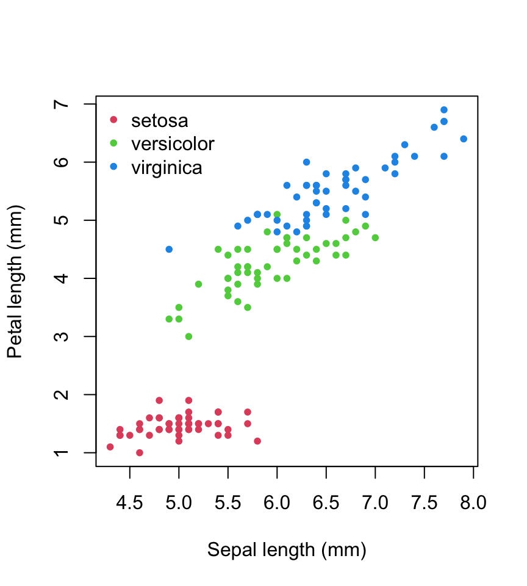

```r
# base graphics
plot(iris$Sepal.Length, iris$Petal.Length, pch = 20,
     col = as.numeric(iris$Species) + 1,
     xlab = "Sepal length (mm)", ylab = "Petal length (mm)")
legend("topleft", levels(iris$Species), pch = 20, col = 2:4, bty = "n")
```

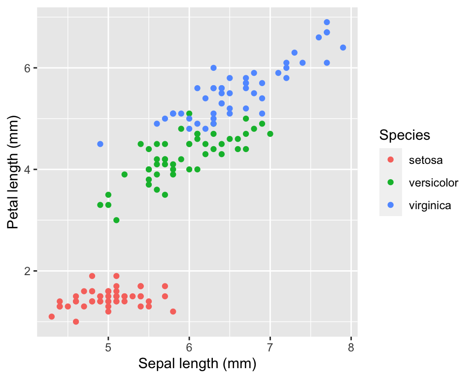

```r
# ggplot2
library(ggplot2)
ggplot(iris, aes(x=Sepal.Length, y=Petal.Length, colour=Species)) +
         geom_point() +
         xlab("Sepal length (mm)") + ylab("Petal length (mm)")
```

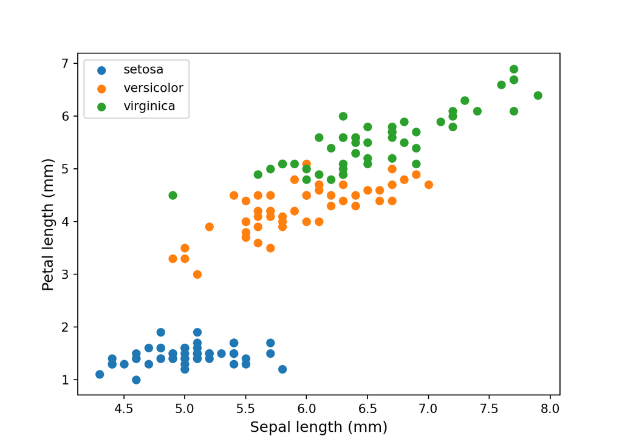

```python
import matplotlib
import matplotlib.pyplot as plt

groups = pyiris.groupby('Species')

fig, ax = plt.subplots()

for name, group in groups:
    ax.scatter(x = group["Sepal.Length"], y = group["Petal.Length"], label=name)
ax.legend()

ax.set_xlabel('Sepal length (mm)', fontsize=12)
ax.set_ylabel('Petal length (mm)', fontsize=12)
plt.show()
```

## 3.11 Working with arrays

Here is a quick summary of how R and Python differ in the way they represent arrays. For a more detailed discussion see this [link](https://rstudio.github.io/reticulate/articles/arrays.html).

Dense data (for example a matrix or 2-dimensional array) are stored contiguously in memory. Array memory ordering schemes translate for example a (row,column) index to a memory address.

R and Python differ in their memory ordering schemes: R is so called “column-major”, meaning that data is layed-out in memory such that the first coordinate is the one changing fastest. The matrix element `x[i, j]` for example can be found at the address offset `a = i + (j - 1) * nrow(x)`.

Python/`NumPy` can store arrays both in “column-major” and also “row-major” form, but it defaults to the “row-major” format. In a row-major layout, the above example element `x[i, j]` would be found at offset `a = j + (i - 1) * ncol(x)`.

If you are using/addressing arrays both in Python and R, it is good to know:

- Dense R arrays are presented to Python/`NumPy` as column-major `NumPy` arrays.
- All `NumPy` arrays (column-major, row-major, otherwise) are presented to R as column-major arrays, because that is the only kind of dense array that R understands.
- R and Python print arrays differently.

The different order of printing may be especially confusing, as illustrated in the exercise below:

- Create a 4 by 3 by 2 (3-dimensional) array containing the numbers 1 to 24 in both Python and R. Hint: in Python, you can use `numpy.arrange` to create the data vector and `numpy.reshape(..., order = "F")` to “fold” it into the desired dimensions (the Fortran-order is required to make it consistent with R). In R, you can use `1:24` to create the data and `array` to fold it.

```python
import numpy as np
aP = np.reshape(np.arange(1,25), (4,3,2), "F")
```

```r
aR <- array(1:24, c(4,3,2))
```

- Print both in each of the two environments

```r
aR
```

```
## , , 1
##
##      [,1] [,2] [,3]
## [1,]    1    5    9
## [2,]    2    6   10
## [3,]    3    7   11
## [4,]    4    8   12
##
## , , 2
##
##      [,1] [,2] [,3]
## [1,]   13   17   21
## [2,]   14   18   22
## [3,]   15   19   23
## [4,]   16   20   24
```

```r
py$aP
```

```
## , , 1
##
##      [,1] [,2] [,3]
## [1,]    1    5    9
## [2,]    2    6   10
## [3,]    3    7   11
## [4,]    4    8   12
##
## , , 2
##
##      [,1] [,2] [,3]
## [1,]   13   17   21
## [2,]   14   18   22
## [3,]   15   19   23
## [4,]   16   20   24
```

```python
r.aR
```

```
## array([[[ 1, 13],
##         [ 5, 17],
##         [ 9, 21]],
##
##        [[ 2, 14],
##         [ 6, 18],
##         [10, 22]],
##
##        [[ 3, 15],
##         [ 7, 19],
##         [11, 23]],
##
##        [[ 4, 16],
##         [ 8, 20],
##         [12, 24]]], dtype=int32)
```

```python
aP
```

```
## array([[[ 1, 13],
##         [ 5, 17],
##         [ 9, 21]],
##
##        [[ 2, 14],
##         [ 6, 18],
##         [10, 22]],
##
##        [[ 3, 15],
##         [ 7, 19],
##         [11, 23]],
##
##        [[ 4, 16],
##         [ 8, 20],
##         [12, 24]]])
```

```python
r.aR.flags
```

```
##   C_CONTIGUOUS : False
##   F_CONTIGUOUS : True
##   OWNDATA : False
##   WRITEABLE : False
##   ALIGNED : True
##   WRITEBACKIFCOPY : False
##   UPDATEIFCOPY : False
```

```python
aP.flags
```

```
##   C_CONTIGUOUS : False
##   F_CONTIGUOUS : True
##   OWNDATA : False
##   WRITEABLE : True
##   ALIGNED : True
##   WRITEBACKIFCOPY : False
##   UPDATEIFCOPY : False
```

- From both environments, print values along just the first index of the first dimension (remember that indexing in R starts at 1 and in Python at 0)

```r
# compare the sub-arrays at the first index of the first dimension
aR[1, , ]
```

```
##      [,1] [,2]
## [1,]    1   13
## [2,]    5   17
## [3,]    9   21
```

```r
py$aP[1, ,]
```

```
##      [,1] [,2]
## [1,]    1   13
## [2,]    5   17
## [3,]    9   21
```

```python
# compare the sub-arrays at the first index of the first dimension
r.aR[0]
```

```
## array([[ 1, 13],
##        [ 5, 17],
##        [ 9, 21]], dtype=int32)
```

```python
aP[0]
```

```
## array([[ 1, 13],
##        [ 5, 17],
##        [ 9, 21]])
```

## 3.12 Working with sparse matrices

If [scipy](https://scipy.org/) is installed, [reticulate](https://rstudio.github.io/reticulate/) will automatically convert R `dgcMatrix` sparse matrix objects to [SciPy CSC matrix](https://docs.scipy.org/doc/scipy/reference/generated/scipy.sparse.csc_matrix.html) objects. Without a working [scipy](https://scipy.org/) installation, the conversion will fail with a “cannot convert object” error. For details see https://rstudio.github.io/reticulate/articles/calling_python.html#sparse-matrices

- Load the `Matrix` package in R and create a sparse matrix

```r
# load Matrix package and create sparse matrix A
library(Matrix)
i <- c(1,3:8)
j <- c(2,9,6:10)
x <- 7 * (1:7)
A <- sparseMatrix(i, j, x = x)
A
```

```
## 8 x 10 sparse Matrix of class "dgCMatrix"
##
## [1,] . 7 . . .  .  .  .  .  .
## [2,] . . . . .  .  .  .  .  .
## [3,] . . . . .  .  .  . 14  .
## [4,] . . . . . 21  .  .  .  .
## [5,] . . . . .  . 28  .  .  .
## [6,] . . . . .  .  . 35  .  .
## [7,] . . . . .  .  .  . 42  .
## [8,] . . . . .  .  .  .  . 49
```

- Access the R sparse matrix from a Python chunk

```python
# automatic conversion to SciPy CSC matrix (requires scipy)
r.A
```

```
## <8x10 sparse matrix of type '<class 'numpy.float64'>'
##  with 7 stored elements in Compressed Sparse Column format>
```

```python
r.A.shape
```

```
## (8, 10)
```

- Explicitely convert the R sparse matrix to a Python object in an R chunk, using the `r_to_py` function. How does it differ from the R matrix? Which process manages the memory allocated for the object?

```r
s1 <- r_to_py(A, convert = FALSE)
s1
```

```
##   (0, 1) 7.0
##   (3, 5) 21.0
##   (4, 6) 28.0
##   (5, 7) 35.0
##   (2, 8) 14.0
##   (6, 8) 42.0
##   (7, 9) 49.0
```

```r
class(s1)
```

```
## [1] "scipy.sparse._csc.csc_matrix"        "scipy.sparse._compressed._cs_matrix"
## [3] "scipy.sparse._data._data_matrix"     "scipy.sparse._base.spmatrix"
## [5] "scipy.sparse._data._minmax_mixin"    "scipy.sparse._index.IndexMixin"
## [7] "python.builtin.object"
```

```r
A
```

```
## 8 x 10 sparse Matrix of class "dgCMatrix"
##
## [1,] . 7 . . .  .  .  .  .  .
## [2,] . . . . .  .  .  .  .  .
## [3,] . . . . .  .  .  . 14  .
## [4,] . . . . . 21  .  .  .  .
## [5,] . . . . .  . 28  .  .  .
## [6,] . . . . .  .  . 35  .  .
## [7,] . . . . .  .  .  . 42  .
## [8,] . . . . .  .  .  .  . 49
```

```r
class(A)
```

```
## [1] "dgCMatrix"
## attr(,"package")
## [1] "Matrix"
```

# 4 Final remarks

- By default when Python objects are returned to R they are converted to their equivalent R types and thus copied. There are ways to prevent that and access the Python object and its methods and properties just as if it was an instance of an R reference class. This may be especially relevant for large objects requiring a substantial fraction of the available memory. See also the `convert` argument of the `py_to_r()` function and https://rstudio.github.io/reticulate/articles/calling_python.html#object-conversion
- R and Python use different default numeric types: Both `3` and `3.0` are interpreted as floating point numbers in R (compare `class(3)` with `class(3.0)` and `class(3L)`). In Python, `3` is interpreted as an integer, and `3.0` as a floating point number. If Python expects an integer, make sure to add L in R (e.g. `3L`).
- Python uses 0-based indices, while R uses 1-based.
- Dots (‘.’) are not allowed in object names in Python. To avoid any issues, it is best to use names for your R objects without any dots.

# 5 Session info

It’s good practise to include information on all used software and their version at the end of an Rmarkdown document. For R, we can use the built-in `sessionInfo()` function (or if you prefer the [sessioninfo](https://cran.rstudio.com/web/packages/sessioninfo/index.html) package), for Python we can for example use the `sinfo` package:

## 5.1 R

```r
date()
```

```
## [1] "Wed Apr 27 11:27:47 2022"
```

[session information not shown]

## 5.2 Python

```python
from sinfo import sinfo
sinfo()
```

[output not shown]